# Day Type Prediction

Joe Gallagher

May 30, 2018

## Introduction

Consumption of WiFi seems emperically to serve as a good proxy for building occupancy in a particular building on Carleton University’s campus. To best understand building occupancy, then, it would be useful to determine what kind of WiFi consumption will occur in the future.

## Data Import/Cleaning

Here, we load in all the relevant packages and bring in our data. We also rearrange it so that it can be easily clustered.

## Clustering and Preliminary Analysis

Here, we include some functions which will be useful for us in exploring different clustering strategies. Let’s first generate elbow plots for each of the floors to see how they would like to be clustered:

Let’s make some plots:

Tweaks to make: * Color?

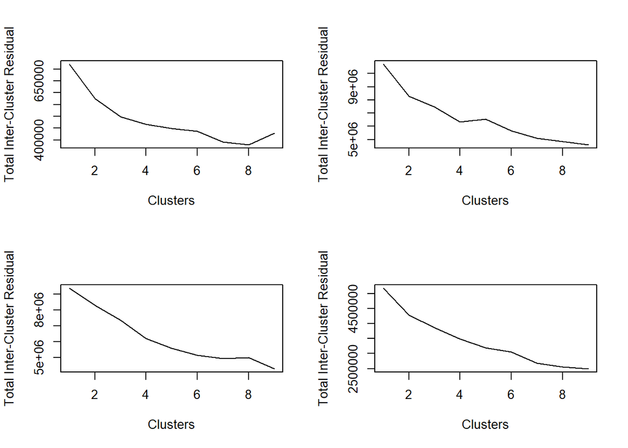

```r
par(mfrow = c(2,2))
elbow_plot(f1_pr, 10)
elbow_plot(f2_pr, 10)
elbow_plot(f3_pr, 10)
elbow_plot(f4_pr, 10)
```

These seem to suggest that, generally, clustering in k < 5 groups is preferable for these floors. For now, let us focus on the first floor as a test case. It has a pronounced elbow at k = 3, so we will cluster it with 3 clusters:

```r
set.seed(77)
c_f1 <- kmeans(f1_pr, centers=3)
```

The centers of these clusters represent “typical” day types. Let us see what these look like.

Tweaks to make:

- Put all these on a single plot
- Make labels meaningful
- Replace dots w/lines
- Make the bottom axis actually show time.
- Give descriptive names to the clusters (e.g. Typ weekday, weekend, unusual weekday)

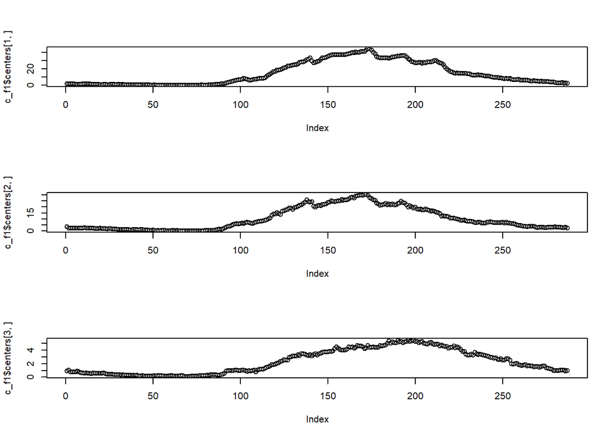

```r
par(mfrow=c(3,1))
plot(c_f1$centers[1,])
plot(c_f1$centers[2,])
plot(c_f1$centers[3,])
```

We include some code which will be useful for what follows:

Let’s see how well we do predicting the cluster as a function of what time we wait until deciding:

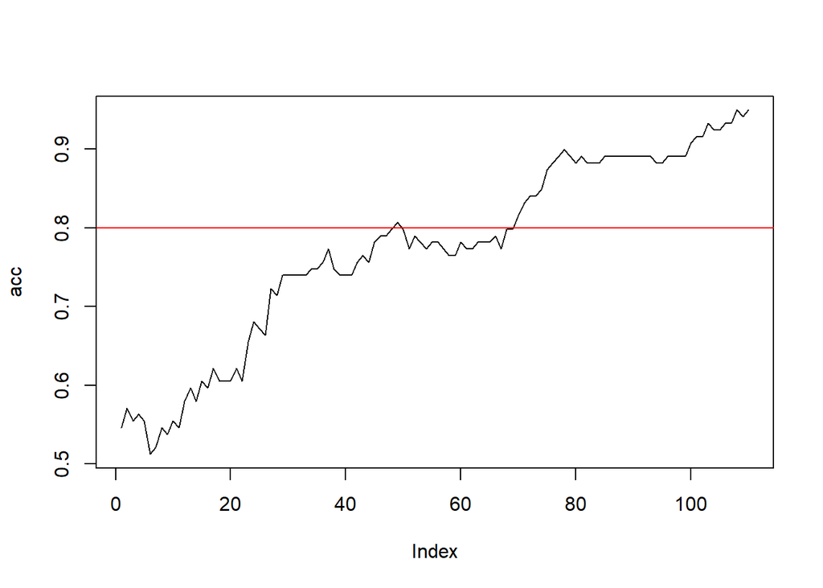

```r
plot_time_acc(f1_pr, c_f1)
abline(h = 0.8, col = "red")
```

It seems that we are able to guess around 80% accurately what type of day we will have once we have observed data through 10:30 AM. How much would using this binning information to predict future occupancy change our average error in person-count versus a baseline of simply predicting an average day?

```r
improve(f1_pr, c_f1, 50)/max(colMeans(f1_pr))
```

```
## [1] 0.2939899 0.4209703
```

Let’s run a similar analysis on the other floors:

```r
a
```

```
##   With Binning Without Binning
## 1    0.2939899       0.4209703
## 2    0.2529865       0.4326854
## 3    0.2766633       0.2910185
## 4    0.2092999       0.2712353
## 5    0.2601397       0.3348920
## 6    0.1677447       0.1789917
## 7    0.1387368       0.1824841
```

```r
b
```

```
##    With Binning Without Binning
##       0.2285087       0.3017539
```